# JarvinenRegression

Niklas Jarvinen

December 14, 2018

```r
library(ggplot2)
library(caret)
library(dplyr)
library(corrplot)
library(GGally)
library(ModelMetrics)
load('HomeRunsNewdf.rdata')
```

Load the libraries and dataframes I created last time.

```r
set.seed(28)
InFit <- createDataPartition(y = HomeRuns$HR, p = .7, list = FALSE)

HR_Fit <- HomeRuns[InFit,]
HR_Accuracy <-HomeRuns[-InFit, ]
```

Split my test and accuracy group.

```r
Fit1 <- lm(HR ~ HR1 + HR2, data = HR_Fit)
summary(Fit1)
```

```
##
## Call:
## lm(formula = HR ~ HR1 + HR2, data = HR_Fit)
##
## Residuals:
##     Min      1Q  Median      3Q     Max
## -16.770  -4.891  -1.864   4.573  20.178
##
## Coefficients:
##             Estimate Std. Error t value Pr(>|t|)
## (Intercept)  5.07260    1.42009   3.572 0.000477 ***
## HR1          0.49345    0.07276   6.782 2.59e-10 ***
## HR2          0.08889    0.06983   1.273 0.204990
## ---
## Signif. codes:  0 '***' 0.001 '**' 0.01 '*' 0.05 '.' 0.1 ' ' 1
##
## Residual standard error: 7.793 on 149 degrees of freedom
##   (98 observations deleted due to missingness)
## Multiple R-squared:  0.3617, Adjusted R-squared:  0.3531
## F-statistic: 42.21 on 2 and 149 DF,  p-value: 2.994e-15
```

For the first model I just wanted to use past home runs totals to see how far it could get me. Turns out that it’s not very far alone. It’s not a bad start but relying on a players past home run totals alone will only get you so far.

```r
Fit2 <- lm(HR ~ PA + Doubles + BBPct + KPct + BB_K + OBP + BABIP + GB_FB + LDPct + GBPct + FBPct + wFB + wSL + wCT + wCB + wCH + wSF + OSwingPct + ZSwingPct + SwingPct + OContactPct + ZContactPct + ContactPct + ZonePct + FStrikePct + SwStrPct + PullPct + CentPct + OppoPct + SoftPct + MedPct + HardPct + HR1 + HR2 + Age2, data = HR_Fit)
summary(Fit2)
```

```
##
## Call:
## lm(formula = HR ~ PA + Doubles + BBPct + KPct + BB_K + OBP +
##     BABIP + GB_FB + LDPct + GBPct + FBPct + wFB + wSL + wCT +
##     wCB + wCH + wSF + OSwingPct + ZSwingPct + SwingPct + OContactPct +
##     ZContactPct + ContactPct + ZonePct + FStrikePct + SwStrPct +
##     PullPct + CentPct + OppoPct + SoftPct + MedPct + HardPct +
##     HR1 + HR2 + Age2, data = HR_Fit)
##
## Residuals:
##    Min     1Q Median     3Q    Max
## -6.863 -1.427 -0.098  1.952  5.186
##
## Coefficients:
##               Estimate Std. Error t value Pr(>|t|)
## (Intercept)  9.517e+02  9.410e+02   1.011  0.31395
## PA           3.846e-02  3.011e-03  12.773  < 2e-16 ***
## Doubles     -2.306e-01  5.005e-02  -4.607 1.06e-05 ***
## BBPct       -1.549e+02  3.485e+01  -4.444 2.03e-05 ***
## KPct         4.938e+01  1.891e+01   2.611  0.01021 *
## BB_K         4.267e+00  4.670e+00   0.914  0.36278
## OBP          4.993e+01  3.881e+01   1.286  0.20086
## BABIP       -1.250e+02  2.313e+01  -5.404 3.52e-07 ***
## GB_FB        1.894e-01  2.341e+00   0.081  0.93566
## LDPct        5.778e+02  5.034e+02   1.148  0.25337
## GBPct        5.976e+02  5.036e+02   1.187  0.23778
## FBPct        6.120e+02  5.038e+02   1.215  0.22689
## wFB          5.008e-01  5.274e-02   9.497 3.58e-16 ***
## wSL          4.402e-01  8.841e-02   4.980 2.24e-06 ***
## wCT          6.945e-01  1.273e-01   5.456 2.79e-07 ***
## wCB          4.423e-01  9.309e-02   4.751 5.84e-06 ***
## wCH          3.945e-01  8.158e-02   4.836 4.10e-06 ***
## wSF          7.142e-01  2.194e-01   3.256  0.00148 **
## OSwingPct   -6.141e+01  1.378e+02  -0.446  0.65670
## ZSwingPct   -4.622e+01  1.033e+02  -0.448  0.65529
## SwingPct     1.283e+02  2.403e+02   0.534  0.59446
## OContactPct -6.706e+00  3.031e+01  -0.221  0.82526
## ZContactPct  9.661e+00  5.044e+01   0.192  0.84846
## ContactPct  -6.686e+01  1.039e+02  -0.644  0.52109
## ZonePct     -6.498e+01  9.153e+01  -0.710  0.47912
## FStrikePct  -1.103e+00  9.880e+00  -0.112  0.91130
## SwStrPct    -1.191e+02  9.754e+01  -1.221  0.22459
## PullPct     -1.009e+03  5.459e+02  -1.849  0.06695 .
## CentPct     -1.004e+03  5.457e+02  -1.840  0.06840 .
## OppoPct     -1.006e+03  5.450e+02  -1.846  0.06746 .
## SoftPct     -4.530e+02  4.825e+02  -0.939  0.34983
## MedPct      -4.457e+02  4.818e+02  -0.925  0.35687
## HardPct     -4.369e+02  4.813e+02  -0.908  0.36593
## HR1          6.079e-02  3.404e-02   1.786  0.07670 .
## HR2          2.561e-02  2.919e-02   0.877  0.38204
## Age2        -9.080e-04  8.577e-02  -0.011  0.99157
## ---
## Signif. codes:  0 '***' 0.001 '**' 0.01 '*' 0.05 '.' 0.1 ' ' 1
##
## Residual standard error: 2.738 on 116 degrees of freedom
##   (98 observations deleted due to missingness)
## Multiple R-squared:  0.9386, Adjusted R-squared:  0.9201
## F-statistic: 50.69 on 35 and 116 DF,  p-value: < 2.2e-16
```

This is just the overfit model with everything that I thought might be relevant, as you can see, there isn’t much that is significant when all of this is put together but interestingly enough it seems as if pitch type is very important, if a hitter can hit each pitch well that would certainly lead to more home runs, but this will be interesting to test out. This model will be hard to beat as far as model fitting goes.

```r
Fit3 <- lm(HR ~ wFB + wCH + wSL + wCT + wCB + wSF, data = HR_Fit)
summary(Fit3)
```

```
##
## Call:
## lm(formula = HR ~ wFB + wCH + wSL + wCT + wCB + wSF, data = HR_Fit)
##
## Residuals:
##     Min      1Q  Median      3Q     Max
## -14.741  -5.034  -0.814   4.498  21.703
##
## Coefficients:
##             Estimate Std. Error t value Pr(>|t|)
## (Intercept) 12.66590    0.47949  26.415  < 2e-16 ***
## wFB          0.51640    0.05068  10.190  < 2e-16 ***
## wCH          0.47709    0.13856   3.443 0.000678 ***
## wSL          0.19737    0.12442   1.586 0.113992
## wCT          0.86470    0.19846   4.357 1.95e-05 ***
## wCB          0.23108    0.15774   1.465 0.144233
## wSF          0.31338    0.41121   0.762 0.446751
## ---
## Signif. codes:  0 '***' 0.001 '**' 0.01 '*' 0.05 '.' 0.1 ' ' 1
##
## Residual standard error: 6.838 on 241 degrees of freedom
##   (2 observations deleted due to missingness)
## Multiple R-squared:  0.4985, Adjusted R-squared:  0.486
## F-statistic: 39.93 on 6 and 241 DF,  p-value: < 2.2e-16
```

Wow! Just the pitch types alone can give us a model that accounts for almost half the data, not too shabby for such a simple model. This is definitely something to keep in mind as I work toward building my “best” model for sure.

```r
Fit4 <- lm(HR ~ OSwingPct + ZSwingPct + SwingPct + OContactPct + ZContactPct + ContactPct + ZonePct + FStrikePct + SwStrPct, data = HR_Fit)
summary(Fit4)
```

```
##
## Call:
## lm(formula = HR ~ OSwingPct + ZSwingPct + SwingPct + OContactPct +
##     ZContactPct + ContactPct + ZonePct + FStrikePct + SwStrPct,
##     data = HR_Fit)
##
## Residuals:
##     Min      1Q  Median      3Q     Max
## -17.252  -5.445  -0.994   4.238  31.056
##
## Coefficients:
##             Estimate Std. Error t value Pr(>|t|)
## (Intercept)   -9.758     92.905  -0.105    0.916
## OSwingPct     15.822    268.524   0.059    0.953
## ZSwingPct     72.715    198.945   0.366    0.715
## SwingPct    -173.981    464.467  -0.375    0.708
## OContactPct   72.594     62.171   1.168    0.244
## ZContactPct  100.725    105.036   0.959    0.339
## ContactPct   -46.765    210.846  -0.222    0.825
## ZonePct     -137.975    172.632  -0.799    0.425
## FStrikePct   -27.772     18.671  -1.487    0.138
## SwStrPct     288.971    190.056   1.520    0.130
##
## Residual standard error: 8.232 on 240 degrees of freedom
## Multiple R-squared:  0.2785, Adjusted R-squared:  0.2515
## F-statistic:  10.3 on 9 and 240 DF,  p-value: 2.067e-13
```

Plate Discipline just does not matter as much as some people think it does. These measures of it put together can only account for 25% of the data, which in a model with this many variables is surprisingly bad in my opinion. I might not use many of these variables in my attempt at a best model, I mean not even one of them is significant.

```r
Fit5 <- lm(HR ~ PullPct + CentPct + OppoPct + SoftPct + MedPct + HardPct + FBPct + GBPct + LDPct, data = HR_Fit)
summary(Fit5)
```

```
##
## Call:
## lm(formula = HR ~ PullPct + CentPct + OppoPct + SoftPct + MedPct +
##     HardPct + FBPct + GBPct + LDPct, data = HR_Fit)
##
## Residuals:
##     Min      1Q  Median      3Q     Max
## -17.812  -5.581  -0.247   3.993  22.853
##
## Coefficients:
##             Estimate Std. Error t value Pr(>|t|)
## (Intercept)   -966.8     1782.2  -0.542    0.588
## PullPct        204.1     1042.1   0.196    0.845
## CentPct        201.9     1041.4   0.194    0.846
## OppoPct        201.2     1040.2   0.193    0.847
## SoftPct       -579.3      995.2  -0.582    0.561
## MedPct        -585.7      994.9  -0.589    0.557
## HardPct       -516.7      994.1  -0.520    0.604
## FBPct         1369.7     1068.4   1.282    0.201
## GBPct         1334.7     1068.4   1.249    0.213
## LDPct         1292.6     1068.0   1.210    0.227
##
## Residual standard error: 7.919 on 240 degrees of freedom
## Multiple R-squared:  0.3323, Adjusted R-squared:  0.3073
## F-statistic: 13.27 on 9 and 240 DF,  p-value: < 2.2e-16
```

Hit type kind of matters but when you blend them altogther you really get mush. It’s better than my plate dicsipline model but not by very much and that isn’t saying much at all.

```r
Fit6 <- lm(HR ~ Age2 + HR1 + HR2 + PA + Doubles + wFB + FBPct + BBPct + HardPct + OBP + PullPct, data = HR_Fit)
summary(Fit6)
```

```
##
## Call:
## lm(formula = HR ~ Age2 + HR1 + HR2 + PA + Doubles + wFB + FBPct +
##     BBPct + HardPct + OBP + PullPct, data = HR_Fit)
##
## Residuals:
##      Min       1Q   Median       3Q      Max
## -13.0533  -3.2183   0.0605   2.9279  10.7388
##
## Coefficients:
##               Estimate Std. Error t value Pr(>|t|)
## (Intercept) -14.275804   7.731467  -1.846 0.066938 .
## Age2          0.276830   0.118230   2.341 0.020619 *
## HR1           0.179623   0.048476   3.705 0.000303 ***
## HR2           0.055639   0.043569   1.277 0.203707
## PA            0.040703   0.004617   8.816 4.19e-15 ***
## Doubles      -0.279986   0.071840  -3.897 0.000150 ***
## wFB           0.468496   0.069108   6.779 3.11e-10 ***
## FBPct        24.123356   7.693805   3.135 0.002092 **
## BBPct       -57.033596  16.876254  -3.380 0.000941 ***
## HardPct      21.487338   7.740451   2.776 0.006257 **
## OBP         -18.335913  20.252446  -0.905 0.366826
## PullPct      12.960685   8.162862   1.588 0.114596
## ---
## Signif. codes:  0 '***' 0.001 '**' 0.01 '*' 0.05 '.' 0.1 ' ' 1
##
## Residual standard error: 4.545 on 140 degrees of freedom
##   (98 observations deleted due to missingness)
## Multiple R-squared:  0.796,  Adjusted R-squared:   0.78
## F-statistic: 49.66 on 11 and 140 DF,  p-value: < 2.2e-16
```

Okay so starting to put everything together here including my handy age variable that I made on the fly that actually kind of is significant here. I think it’s amazing how much more 2017 home runs mattered more than 2016 home runs. This model is a very good start which makes sense considering I only used variables I found to have positive correlation and just used my baseball and stats knowledge to put it together, but it’s not quite where it should be, there’s stuff still missing that in this dataset I could definitely use to better it.

```r
Fit7 <- lm(HR ~ Age2 + HR1 + HR2 + PA + Doubles + wFB + FBPct + BBPct + HardPct + OBP + PullPct + GBPct + ZonePct + MedPct, data = HR_Fit)
summary(Fit7)
```

```
##
## Call:
## lm(formula = HR ~ Age2 + HR1 + HR2 + PA + Doubles + wFB + FBPct +
##     BBPct + HardPct + OBP + PullPct + GBPct + ZonePct + MedPct,
##     data = HR_Fit)
##
## Residuals:
##     Min      1Q  Median      3Q     Max
## -13.382  -2.661   0.231   2.649  11.246
##
## Coefficients:
##               Estimate Std. Error t value Pr(>|t|)
## (Intercept) -46.402895  19.803129  -2.343 0.020558 *
## Age2          0.094960   0.117838   0.806 0.421724
## HR1           0.145865   0.048097   3.033 0.002899 **
## HR2           0.013905   0.041638   0.334 0.738937
## PA            0.037923   0.004371   8.677 1.06e-14 ***
## Doubles      -0.196292   0.069916  -2.808 0.005721 **
## wFB           0.415260   0.065670   6.323 3.37e-09 ***
## FBPct        78.105650  15.177273   5.146 9.03e-07 ***
## BBPct       -61.052272  16.130841  -3.785 0.000229 ***
## HardPct      19.767933  11.428002   1.730 0.085922 .
## OBP           5.096865  19.607434   0.260 0.795296
## PullPct       7.551709   7.699839   0.981 0.328439
## GBPct        52.770720  12.947100   4.076 7.73e-05 ***
## ZonePct     -18.729027  21.151020  -0.885 0.377444
## MedPct      -11.262302  13.198737  -0.853 0.394990
## ---
## Signif. codes:  0 '***' 0.001 '**' 0.01 '*' 0.05 '.' 0.1 ' ' 1
##
## Residual standard error: 4.241 on 137 degrees of freedom
##   (98 observations deleted due to missingness)
## Multiple R-squared:  0.8261, Adjusted R-squared:  0.8084
## F-statistic: 46.49 on 14 and 137 DF,  p-value: < 2.2e-16
```

That stuff can start by “adding” in the things with high or medium negative correlations to make the model better, and it does this but only ever so slightly. Not good enough for me.

```r
Fit8 <- lm(HR ~ Age2 + HR1 + HR2 + PA + Doubles + wFB + wCB + wSL + wCH + wSF + wCT + FBPct + BBPct + HardPct + OBP + PullPct + GBPct + ZonePct + MedPct, data = HR_Fit)
summary(Fit8)
```

```
##
## Call:
## lm(formula = HR ~ Age2 + HR1 + HR2 + PA + Doubles + wFB + wCB +
##     wSL + wCH + wSF + wCT + FBPct + BBPct + HardPct + OBP + PullPct +
##     GBPct + ZonePct + MedPct, data = HR_Fit)
##
## Residuals:
##     Min      1Q  Median      3Q     Max
## -7.6697 -2.0289  0.1697  1.6663  7.5475
##
## Coefficients:
##               Estimate Std. Error t value Pr(>|t|)
## (Intercept)  7.093e+00  1.504e+01   0.472  0.63800
## Age2        -8.776e-02  8.746e-02  -1.003  0.31746
## HR1          7.417e-02  3.526e-02   2.104  0.03731 *
## HR2          3.281e-02  3.013e-02   1.089  0.27811
## PA           3.836e-02  3.166e-03  12.116  < 2e-16 ***
## Doubles     -2.756e-01  5.137e-02  -5.364 3.53e-07 ***
## wFB          6.145e-01  5.062e-02  12.140  < 2e-16 ***
## wCB          4.934e-01  9.588e-02   5.146 9.41e-07 ***
## wSL          4.425e-01  8.653e-02   5.113 1.09e-06 ***
## wCH          4.573e-01  8.464e-02   5.403 2.96e-07 ***
## wSF          7.008e-01  2.364e-01   2.965  0.00360 **
## wCT          8.609e-01  1.188e-01   7.246 3.21e-11 ***
## FBPct        6.156e+01  1.109e+01   5.553 1.49e-07 ***
## BBPct       -2.080e+01  1.230e+01  -1.691  0.09319 .
## HardPct      2.248e+01  8.286e+00   2.713  0.00756 **
## OBP         -1.324e+02  1.879e+01  -7.045 9.22e-11 ***
## PullPct      7.426e+00  5.596e+00   1.327  0.18681
## GBPct        4.384e+01  9.388e+00   4.670 7.31e-06 ***
## ZonePct     -4.312e+01  1.544e+01  -2.793  0.00600 **
## MedPct       6.155e+00  9.688e+00   0.635  0.52628
## ---
## Signif. codes:  0 '***' 0.001 '**' 0.01 '*' 0.05 '.' 0.1 ' ' 1
##
## Residual standard error: 3.035 on 132 degrees of freedom
##   (98 observations deleted due to missingness)
## Multiple R-squared:  0.9142, Adjusted R-squared:  0.9018
## F-statistic: 74.02 on 19 and 132 DF,  p-value: < 2.2e-16
```

Now here I’m trying to add in the pitch linear weights since they did so well by themselves and it actually really helps my adjusted R squared, which is what I am looking at in this case since it penalizes you for adding variables. Pitch weights really do matter a lot, and while there may be some multicollinearity since home runs are weighted more in this stat, I don’t think it is enough to not use these seemingly really important variables.

```r
Fit9 <- lm(HR ~ Age2 + HR1 + + PA + Doubles + wFB + wCB + wSL + wCH + wSF + wCT + FBPct + BBPct + HardPct + OBP + GBPct + ZonePct, data = HR_Fit)
summary(Fit9)
```

```
##
## Call:
## lm(formula = HR ~ Age2 + HR1 + +PA + Doubles + wFB + wCB + wSL +
##     wCH + wSF + wCT + FBPct + BBPct + HardPct + OBP + GBPct +
##     ZonePct, data = HR_Fit)
##
## Residuals:
##     Min      1Q  Median      3Q     Max
## -9.2565 -2.0088  0.1183  1.8738  8.8324
##
## Coefficients:
##               Estimate Std. Error t value Pr(>|t|)
## (Intercept)  9.275e+00  1.266e+01   0.733  0.46477
## Age2        -2.535e-02  7.533e-02  -0.337  0.73688
## HR1          9.190e-02  3.037e-02   3.026  0.00285 **
## PA           4.146e-02  3.081e-03  13.457  < 2e-16 ***
## Doubles     -3.267e-01  4.979e-02  -6.562 5.59e-10 ***
## wFB          5.917e-01  4.607e-02  12.843  < 2e-16 ***
## wCB          4.490e-01  8.835e-02   5.082 9.39e-07 ***
## wSL          4.940e-01  7.696e-02   6.419 1.21e-09 ***
## wCH          4.354e-01  8.047e-02   5.411 2.00e-07 ***
## wSF          6.873e-01  2.339e-01   2.938  0.00374 **
## wCT          6.993e-01  1.104e-01   6.336 1.87e-09 ***
## FBPct        5.846e+01  9.240e+00   6.327 1.97e-09 ***
## BBPct       -1.748e+01  1.168e+01  -1.497  0.13620
## HardPct      2.339e+01  4.734e+00   4.940 1.79e-06 ***
## OBP         -1.187e+02  1.778e+01  -6.679 2.96e-10 ***
## GBPct        3.749e+01  8.281e+00   4.527 1.09e-05 ***
## ZonePct     -3.695e+01  1.393e+01  -2.653  0.00871 **
## ---
## Signif. codes:  0 '***' 0.001 '**' 0.01 '*' 0.05 '.' 0.1 ' ' 1
##
## Residual standard error: 3.248 on 178 degrees of freedom
##   (55 observations deleted due to missingness)
## Multiple R-squared:  0.8974, Adjusted R-squared:  0.8882
## F-statistic:  97.3 on 16 and 178 DF,  p-value: < 2.2e-16
```

I just took out the non-significant variables here from last model to try and imrpove my model, but it makes it worse in the end.

```r
Fit10 <- lm(HR ~ Age2 + HR1 + + PA + Doubles + wFB + wCB + wSL + wCH + wSF + wCT + FBPct + HardPct + OBP + GBPct + ZonePct, data = HR_Fit)
summary(Fit10)
```

```
##
## Call:
## lm(formula = HR ~ Age2 + HR1 + +PA + Doubles + wFB + wCB + wSL +
##     wCH + wSF + wCT + FBPct + HardPct + OBP + GBPct + ZonePct,
##     data = HR_Fit)
##
## Residuals:
##     Min      1Q  Median      3Q     Max
## -8.3404 -1.9966 -0.0064  2.0176  8.9105
##
## Coefficients:
##               Estimate Std. Error t value Pr(>|t|)
## (Intercept)  1.717e+01  1.155e+01   1.487  0.13880
## Age2        -4.151e-02  7.481e-02  -0.555  0.57965
## HR1          8.662e-02  3.027e-02   2.861  0.00472 **
## PA           4.141e-02  3.091e-03  13.395  < 2e-16 ***
## Doubles     -3.084e-01  4.843e-02  -6.368 1.56e-09 ***
## wFB          5.948e-01  4.619e-02  12.878  < 2e-16 ***
## wCB          4.579e-01  8.845e-02   5.176 6.04e-07 ***
## wSL          5.207e-01  7.512e-02   6.932 7.27e-11 ***
## wCH          4.593e-01  7.915e-02   5.803 2.90e-08 ***
## wSF          7.411e-01  2.320e-01   3.195  0.00165 **
## wCT          7.271e-01  1.092e-01   6.659 3.26e-10 ***
## FBPct        5.398e+01  8.773e+00   6.153 4.84e-09 ***
## HardPct      2.202e+01  4.662e+00   4.724 4.66e-06 ***
## OBP         -1.344e+02  1.443e+01  -9.317  < 2e-16 ***
## GBPct        3.528e+01  8.177e+00   4.315 2.64e-05 ***
## ZonePct     -4.079e+01  1.374e+01  -2.969  0.00339 **
## ---
## Signif. codes:  0 '***' 0.001 '**' 0.01 '*' 0.05 '.' 0.1 ' ' 1
##
## Residual standard error: 3.259 on 179 degrees of freedom
##   (55 observations deleted due to missingness)
## Multiple R-squared:  0.8961, Adjusted R-squared:  0.8874
## F-statistic: 102.9 on 15 and 179 DF,  p-value: < 2.2e-16
```

Just tried to take walk percentage out of the picture since it seems to be a bad indicator of home runs but there is no luck here. It’s basically the same fit.

```r
Fit11 <- lm(HR ~ Age2 + PA + Doubles + wFB + wCB + wSL + wCH + wSF + wCT + FBPct + BBPct + HardPct + OBP + PullPct + GBPct + ZonePct + MedPct, data = HR_Fit)
summary(Fit11)
```

```
##
## Call:
## lm(formula = HR ~ Age2 + PA + Doubles + wFB + wCB + wSL + wCH +
##     wSF + wCT + FBPct + BBPct + HardPct + OBP + PullPct + GBPct +
##     ZonePct + MedPct, data = HR_Fit)
##
## Residuals:
##      Min       1Q   Median       3Q      Max
## -10.0826  -2.0190   0.1143   2.0092   8.6530
##
## Coefficients:
##               Estimate Std. Error t value Pr(>|t|)
## (Intercept)  1.518e+01  1.302e+01   1.166 0.244940
## Age2        -4.618e-03  6.215e-02  -0.074 0.940827
## PA           4.393e-02  2.746e-03  15.997  < 2e-16 ***
## Doubles     -3.484e-01  4.641e-02  -7.508 1.32e-12 ***
## wFB          5.870e-01  4.104e-02  14.303  < 2e-16 ***
## wCB          4.497e-01  8.406e-02   5.350 2.13e-07 ***
## wSL          4.617e-01  6.857e-02   6.733 1.31e-10 ***
## wCH          4.645e-01  7.341e-02   6.327 1.29e-09 ***
## wSF          6.506e-01  2.086e-01   3.119 0.002043 **
## wCT          7.270e-01  9.940e-02   7.314 4.28e-12 ***
## FBPct        5.037e+01  8.796e+00   5.726 3.19e-08 ***
## BBPct       -8.490e+00  1.040e+01  -0.816 0.415200
## HardPct      2.418e+01  6.701e+00   3.609 0.000378 ***
## OBP         -1.133e+02  1.467e+01  -7.721 3.52e-13 ***
## PullPct      8.521e+00  4.523e+00   1.884 0.060809 .
## GBPct        3.138e+01  7.748e+00   4.050 7.00e-05 ***
## ZonePct     -5.161e+01  1.177e+01  -4.383 1.78e-05 ***
## MedPct       1.038e+00  7.749e+00   0.134 0.893519
## ---
## Signif. codes:  0 '***' 0.001 '**' 0.01 '*' 0.05 '.' 0.1 ' ' 1
##
## Residual standard error: 3.269 on 230 degrees of freedom
##   (2 observations deleted due to missingness)
## Multiple R-squared:  0.8906, Adjusted R-squared:  0.8825
## F-statistic: 110.1 on 17 and 230 DF,  p-value: < 2.2e-16
```

Just made a model here for players with no past HR data to run through, since seemingly only the past season matters when it comes to hitting the home runs, so it only needs to be used on guys like Ronald Acuna Jr. who were rookies.

```r
Predictlm1 <- predict(Fit1, newdata=HR_Accuracy)
Predictlm2 <- predict(Fit2, newdata=HR_Accuracy)
Predictlm3 <- predict(Fit3, newdata=HR_Accuracy)
Predictlm4 <- predict(Fit4, newdata=HR_Accuracy)
Predictlm5 <- predict(Fit5, newdata=HR_Accuracy)
Predictlm6 <- predict(Fit6, newdata=HR_Accuracy)
Predictlm7 <- predict(Fit7, newdata=HR_Accuracy)
Predictlm8 <- predict(Fit8, newdata=HR_Accuracy)
Predictlm9 <- predict(Fit9, newdata=HR_Accuracy)
Predictlm10 <- predict(Fit10, newdata=HR_Accuracy)
Predictlm11 <- predict(Fit11, newdata=HR_Accuracy)
```

```r
AccuracyDF <- data.frame(AllFitTotal=HR_Accuracy[,"HR"],
                          Fit1Total=Predictlm1,
                          Fit2Total=Predictlm2,
                          Fit3Total=Predictlm3,
                          Fit4Total=Predictlm4,
                          Fit5Total=Predictlm5,
                          Fit6Total=Predictlm6,
                          Fit7Total=Predictlm7,
                          Fit8Total=Predictlm8,
                          Fit9Total=Predictlm9,
                          Fit10Total=Predictlm10,
                          Fit11Total=Predictlm11)

head(AccuracyDF)
```

```
##   HR Fit1Total Fit2Total Fit3Total Fit4Total Fit5Total Fit6Total Fit7Total
## 1 26        NA        NA  27.54929  19.30801  22.55985        NA        NA
## 2 14        NA        NA  17.76035  17.50555  21.37453        NA        NA
## 3 17        NA        NA  16.69217  12.73863  16.91378        NA        NA
## 4 11        NA        NA  15.25257  11.95422  13.67511        NA        NA
## 5 27        NA        NA  16.81445  20.33075  17.23530        NA        NA
## 6 11        NA        NA  15.14100  16.39509  10.01222        NA        NA
##   Fit8Total Fit9Total Fit10Total Fit11Total
## 1        NA        NA         NA   28.82580
## 2        NA        NA         NA   19.06644
## 3        NA        NA         NA   14.52955
## 4        NA        NA         NA   16.53503
## 5        NA        NA         NA   26.03251
## 6        NA        NA         NA   10.89779
```

```r
tail(AccuracyDF)
```

```
##     HR Fit1Total  Fit2Total Fit3Total Fit4Total Fit5Total Fit6Total
## 100  2        NA         NA  8.324400  4.669475 15.590932        NA
## 101  9  7.490887 10.0457282 13.331423 12.562484  8.226627  5.092443
## 102  8  7.490887  6.3204578 13.943167  6.318267 12.451935  5.616915
## 103  3  6.681769  0.9236033  9.694710 12.155456  9.842009 -3.608426
## 104  3  6.237297 10.6479712  8.214017  8.220245  5.551737  8.765803
## 105 10        NA         NA 14.434668 13.534421 15.006187        NA
##     Fit7Total Fit8Total  Fit9Total Fit10Total Fit11Total
## 100        NA        NA  2.9808718   3.355607  3.5619189
## 101  6.305980 6.3333225  6.3875288   6.178563  7.4170104
## 102  4.989432 7.4162076  7.0824852   6.735555  7.4718145
## 103 -2.717356 0.5214327 -0.5306656   0.169118  0.6494398
## 104  8.474657 7.0624865  8.2829729   8.074054  9.1480070
## 105        NA        NA  8.5101726   7.979473  9.3764166
```

```r
names(AccuracyDF)[1] <- "AllFitTotal"
head(AccuracyDF)
```

```
##   AllFitTotal Fit1Total Fit2Total Fit3Total Fit4Total Fit5Total Fit6Total
## 1          26        NA        NA  27.54929  19.30801  22.55985        NA
## 2          14        NA        NA  17.76035  17.50555  21.37453        NA
## 3          17        NA        NA  16.69217  12.73863  16.91378        NA
## 4          11        NA        NA  15.25257  11.95422  13.67511        NA
## 5          27        NA        NA  16.81445  20.33075  17.23530        NA
## 6          11        NA        NA  15.14100  16.39509  10.01222        NA
##   Fit7Total Fit8Total Fit9Total Fit10Total Fit11Total
## 1        NA        NA        NA         NA   28.82580
## 2        NA        NA        NA         NA   19.06644
## 3        NA        NA        NA         NA   14.52955
## 4        NA        NA        NA         NA   16.53503
## 5        NA        NA        NA         NA   26.03251
## 6        NA        NA        NA         NA   10.89779
```

```r
tot_rmse_lm1 <- sqrt(with(AccuracyDF,sum((AllFitTotal - Fit1Total)^2, na.rm = TRUE))/nrow(AccuracyDF))
tot_rmse_lm2 <- sqrt(with(AccuracyDF,sum((AllFitTotal - Fit2Total)^2, na.rm = TRUE))/nrow(AccuracyDF))
tot_rmse_lm3 <- sqrt(with(AccuracyDF,sum((AllFitTotal - Fit3Total)^2, na.rm = TRUE))/nrow(AccuracyDF))
tot_rmse_lm4 <- sqrt(with(AccuracyDF,sum((AllFitTotal - Fit4Total)^2, na.rm = TRUE))/nrow(AccuracyDF))
tot_rmse_lm5 <- sqrt(with(AccuracyDF,sum((AllFitTotal - Fit5Total)^2, na.rm = TRUE))/nrow(AccuracyDF))
tot_rmse_lm6 <- sqrt(with(AccuracyDF,sum((AllFitTotal - Fit6Total)^2, na.rm = TRUE))/nrow(AccuracyDF))
tot_rmse_lm7 <- sqrt(with(AccuracyDF,sum((AllFitTotal - Fit7Total)^2, na.rm = TRUE))/nrow(AccuracyDF))
tot_rmse_lm8 <- sqrt(with(AccuracyDF,sum((AllFitTotal - Fit8Total)^2, na.rm = TRUE))/nrow(AccuracyDF))
tot_rmse_lm9 <- sqrt(with(AccuracyDF,sum((AllFitTotal - Fit9Total)^2, na.rm = TRUE))/nrow(AccuracyDF))
tot_rmse_lm10 <- sqrt(with(AccuracyDF,sum((AllFitTotal - Fit10Total)^2, na.rm = TRUE))/nrow(AccuracyDF))
tot_rmse_lm11 <- sqrt(with(AccuracyDF,sum((AllFitTotal - Fit11Total)^2, na.rm = TRUE))/nrow(AccuracyDF))
```

```r
tot_rmse_lm1
```

```
## [1] 5.346815
```

```r
tot_rmse_lm2
```

```
## [1] 2.422738
```

```r
tot_rmse_lm3
```

```
## [1] 6.211347
```

```r
tot_rmse_lm4
```

```
## [1] 7.62124
```

```r
tot_rmse_lm5
```

```
## [1] 6.541327
```

```r
tot_rmse_lm6
```

```
## [1] 3.463343
```

```r
tot_rmse_lm7
```

```
## [1] 3.507315
```

```r
tot_rmse_lm8
```

```
## [1] 2.847652
```

```r
tot_rmse_lm9
```

```
## [1] 3.157636
```

```r
tot_rmse_lm10
```

```
## [1] 3.151543
```

```r
tot_rmse_lm11
```

```
## [1] 3.642765
```

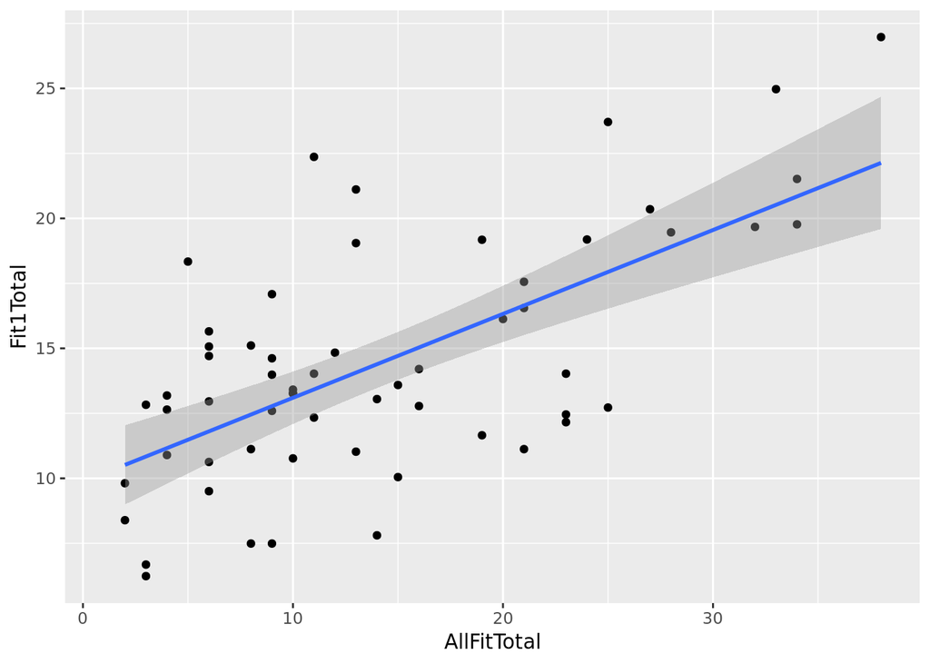

```r
ggplot(data=AccuracyDF, aes(x=AllFitTotal,y=Fit1Total)) + geom_point() + geom_smooth(method = "lm")
```

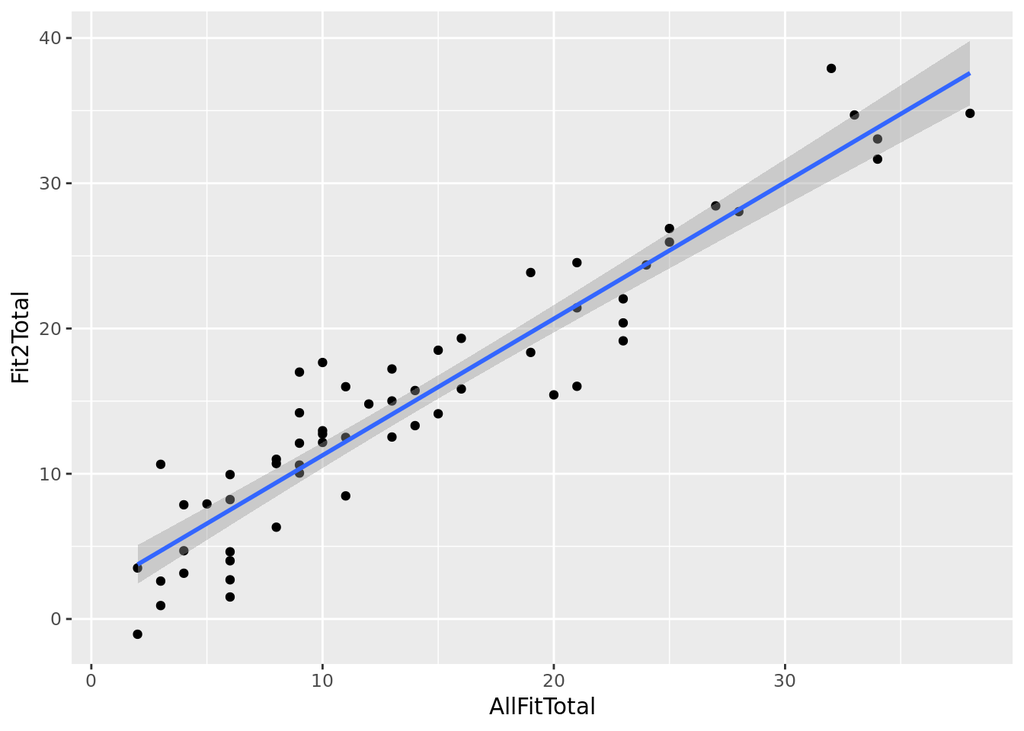

```r
ggplot(data=AccuracyDF, aes(x=AllFitTotal,y=Fit2Total)) + geom_point() + geom_smooth(method = "lm")
```

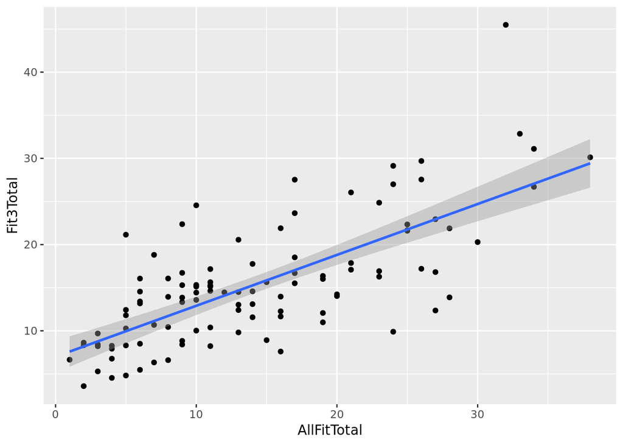

```r
ggplot(data=AccuracyDF, aes(x=AllFitTotal,y=Fit3Total)) + geom_point() + geom_smooth(method = "lm")
```

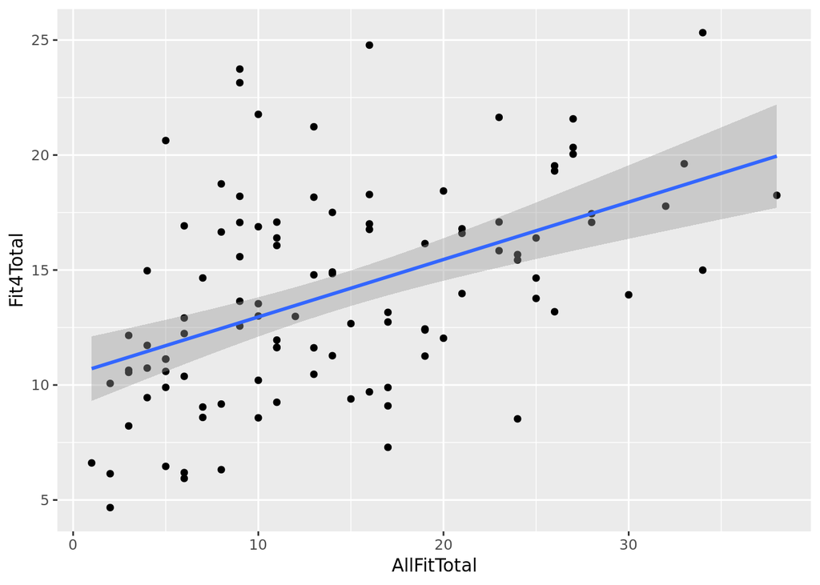

```r
ggplot(data=AccuracyDF, aes(x=AllFitTotal,y=Fit4Total)) + geom_point() + geom_smooth(method = "lm")
```

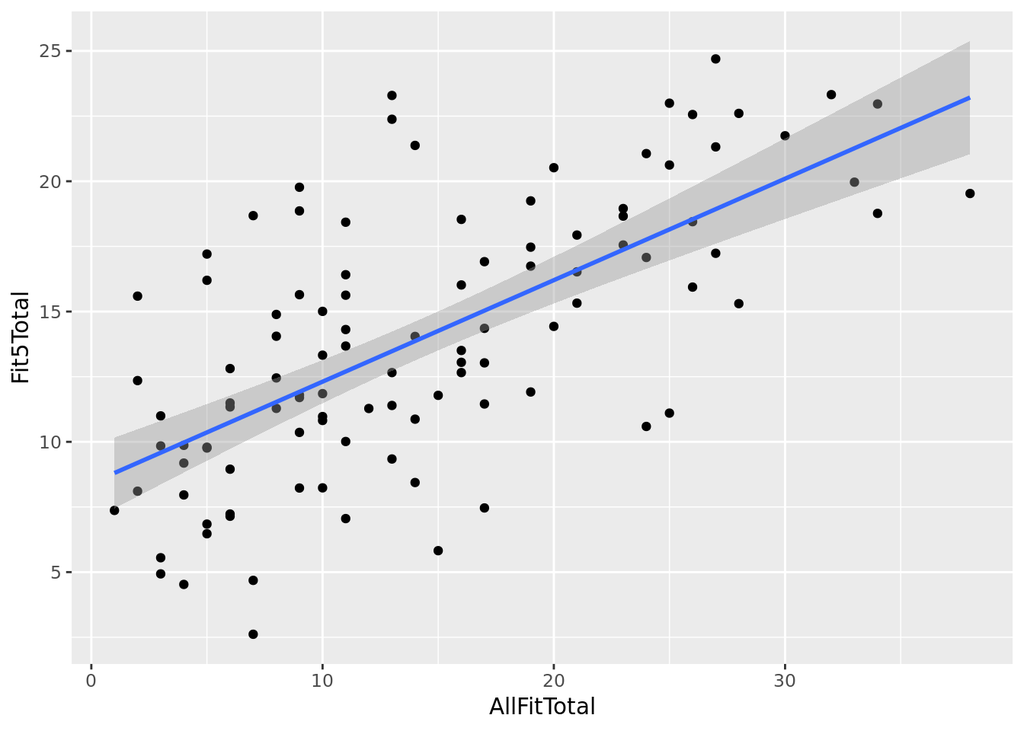

```r
ggplot(data=AccuracyDF, aes(x=AllFitTotal,y=Fit5Total)) + geom_point() + geom_smooth(method = "lm")
```

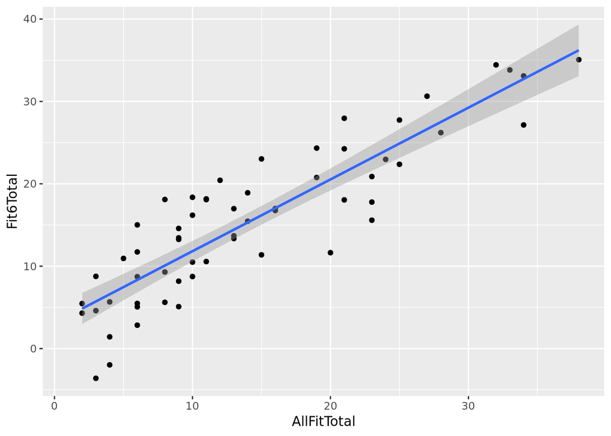

```r
ggplot(data=AccuracyDF, aes(x=AllFitTotal,y=Fit6Total)) + geom_point() + geom_smooth(method = "lm")
```

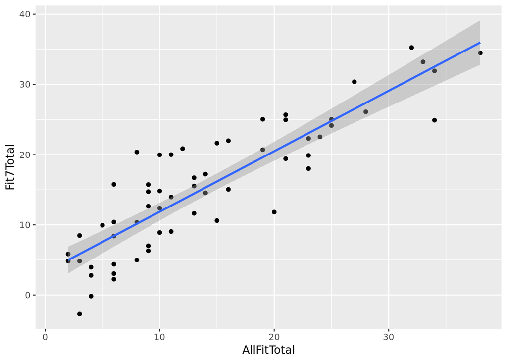

```r
ggplot(data=AccuracyDF, aes(x=AllFitTotal,y=Fit7Total)) + geom_point() + geom_smooth(method = "lm")
```

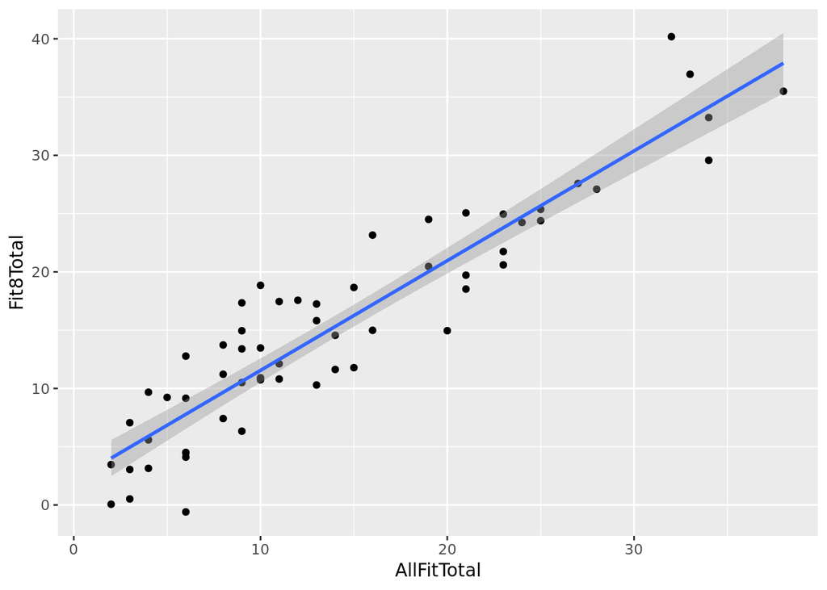

```r
ggplot(data=AccuracyDF, aes(x=AllFitTotal,y=Fit8Total)) + geom_point() + geom_smooth(method = "lm")
```

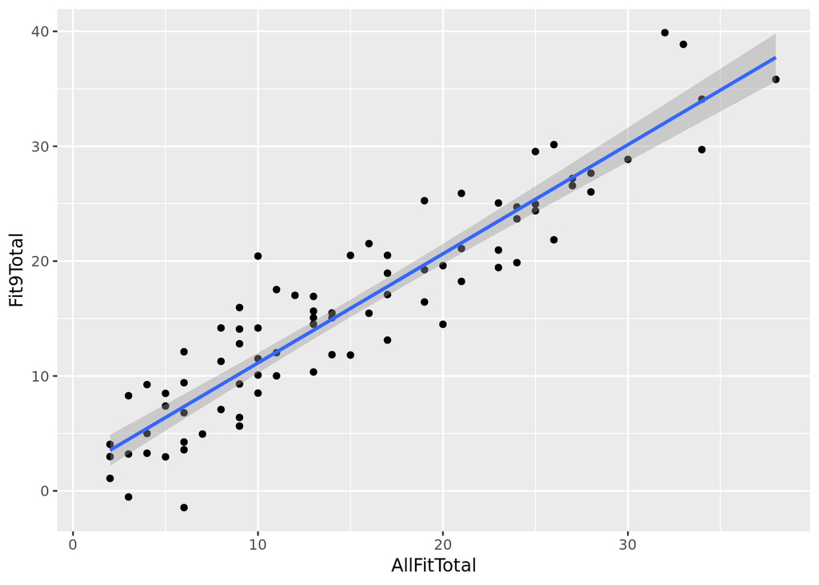

```r
ggplot(data=AccuracyDF, aes(x=AllFitTotal,y=Fit9Total)) + geom_point() + geom_smooth(method = "lm")
```

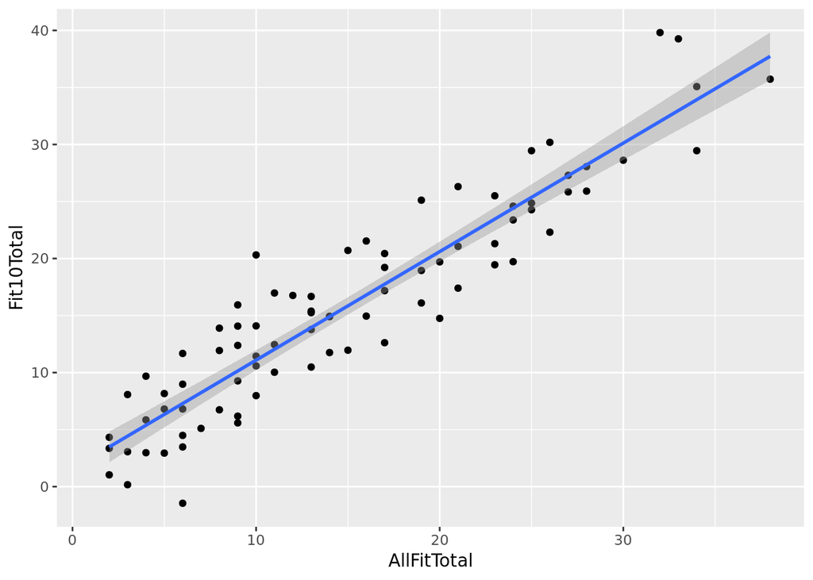

```r
ggplot(data=AccuracyDF, aes(x=AllFitTotal,y=Fit10Total)) + geom_point() + geom_smooth(method = "lm")
```

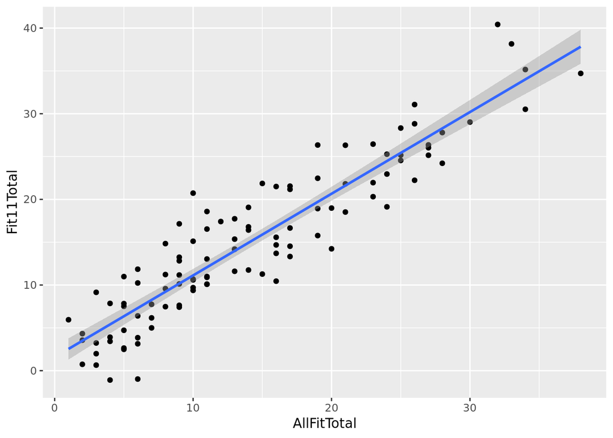

```r
ggplot(data=AccuracyDF, aes(x=AllFitTotal,y=Fit11Total)) + geom_point() + geom_smooth(method = "lm")
```